# R Programming

## Introduction

[figure not shown]

### About Me

- U.S. Air Force - Operations Research Analyst
- Air Force Institute of Technology - Assistant Professor
- University of Cincinnati - Adjunct Assistant Professor
- Website: bradleyboehmke.github.io
- Twitter: [@bradleyboehmke](https://twitter.com/bradleyboehmke)
- Code: [GitHub](https://github.com/bradleyboehmke)

## Short Course Information

### Instructor

- Me

### Time & Location

- Time: 1:15 - 4:15
- Location: Lindner 608

### Website

- Companion website: [uc-r.github.io](http://uc-r.github.io/)
- Slides: uc-r.github.io/r_bootcamp

### What are we doing?

- Day 1: R Programming literacy
- Day 2: Data visualization

### Requirements

- Computer
- R
- IDE (i.e. RStudio)
- Internet (not absolute)

## Short Course Description & Objectives

> *Provides an intensive, hands-on introduction to the R programming language. Prepares students with the fundamental programming skills required to start your journey to becoming a modern day data analyst.*

### Today

- Getting started with R
- Importing data into R
- Understanding data structures
- Understanding data types
- Shaping and transforming your data
- Descriptive statistics

### Tomorrow

- Base R graphics
- ggplot graphics library
- visualizing distributions
- visualizing categorical data
- visualizing 2 variables
- visualizing time series
- visualizing 3+ variables

## Analytics & Programming

## Why Program?

## Why Program?

### Flexibility

- Frees us from point-n-click analysis software
- Allows us to customize our analyses
- Allows us to build analytic applications

### Slows us down

- Forces us to think about our analytic processes

### Speeds the analysis up

- Many statistical programming languages now leverage C++ and Java to speed up computation time

### Reproducibility

- Provides reproducibility that spreadsheet analysis cannot
- Literate statistical programming is on the rise

## Why R?

## Why R?

### Built for Analytics!

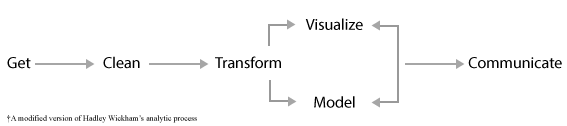

## Why R?

### Built for Analytics!

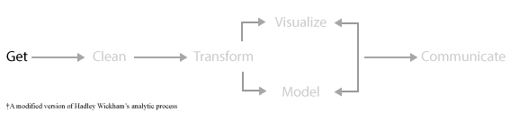

- .csv, .txt, .xls, etc. files
- web scraping
- databases: MySQL, Oracle, PostgreSQL, etc.
- SPSS, Stat, SAS

## Why R?

### Built for Analytics!

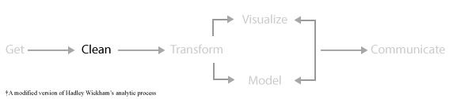

- easy to create "tidy" data
- works well with numerics, characters, dates, missing values
- robust regex capabilities

## Why R?

### Built for Analytics!

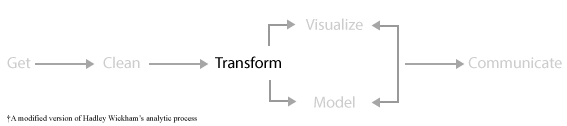

- joining disparate data sets
- selecting, filtering, summarizing
- great "pipe-line" process

## Why R?

### Built for Analytics!

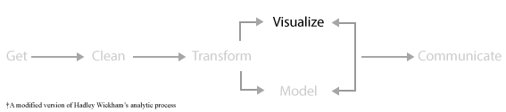

- R is known for its visualization capabilities
- ggplot
- interactive plotting - easily leverage D3.js libraries

## Why R?

### Built for Analytics!

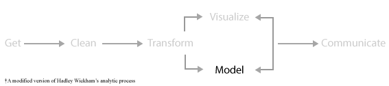

- built for statistical analyses
- thousands of libraries provide many statistical capabilities
- easy to build your own algorithms

## Why R?

### Built for Analytics!

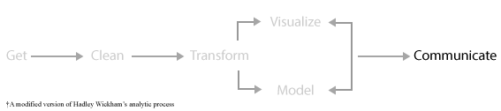

- RMarkdown (produce slides, HTML web pages, pdf)
- Shiny
- Reproducibility (communicate to your future self!)

## Why R?

### Great Community!

[figure not shown]

## Why R?

### Create Cool Stuff!

[figure not shown]

## Getting Started

*“Programming is like kicking yourself in the face, sooner or later your nose will bleed.”*

- Kyle Woodbury

## Installation

1. Go to https://cran.r-project.org/
2. Click "Download R for Mac/Windows"
3. Download the appropriate file:
   - Windows users click Base, and download the installer for the latest R version
   - Mac users select the file R-3.X.X.pkg that aligns with your OS version
4. Follow the instructions of the installer.
1. Go to RStudio for desktop https://www.rstudio.com/products/rstudio/download/
2. Select the install file for your OS
3. Follow the instructions of the installer.

**Note:** There are other R IDE's available: [Emacs](https://www.gnu.org/software/emacs/), [Microsoft R Open](http://revolutionanalytics.com/microsoft-r-open), [Notepad++](https://notepad-plus-plus.org/), etc.

## Understanding the Console

[figure not shown]

Thorough [tutorial regarding the RStudio console](http://dss.princeton.edu/training/RStudio101.pdf)

## Getting Help

Numerous help options are available internal and external to R. Within R, you can get help by:

```r
# provides details for specific function
help(functionname)

# provides same information as help(functionname)
?functionname

# provides examples for said function
example(functionname)
```

External to R:

- `RSiteSearch("key phrase")`: searches for the key phrase in help manuals and archived mailing lists on the [R Project website](http://search.r-%20project.org/).
- [**Stack Overflow:**](http://stackoverflow.com/) a searchable Q&A site oriented toward programming issues. 75% of my answers typically come from Stack Overflow.
- [**Cross Validated:**](http://stats.stackexchange.com/) a searchable Q&A site oriented toward statistical analysis.
- [**R-seek:**](http://rseek.org) a Google custom search that is focused on R-specific websites
- [**R-bloggers:**](http://www.r-%20bloggers.com/) a central hub of content from over 500 bloggers who provide news and tutorials about R.

## Set Your Directory

- Keeping your files organized is critical
- Get and set your working directory with the following:

```r
# get your current working directory
getwd()
[1] "/Users/bradboehmke/Dropbox/Academia/University of Cincinnati/Intro to R Bootcamp"

# set your working directory
setwd("/Users/bradboehmke/Dropbox/Academia/University of Cincinnati")

getwd()
[1] "/Users/bradboehmke/Dropbox/Academia/University of Cincinnati"
```

## Your Turn

> Set your working directory to the "R-Bootcamp" folder you downloaded for this course.